# FitBit Data Analysis & Report

Amadea Franstella Tanugerah, Christina Erica Sugianto, and Maria Fabiola Pratiwi

Thursday, May 6 2021

### Using K-Means Clustering and Regression Tree to Predict Calories Burned

The objective of this report are as follows:  
1. To **analyze** the dataset collected using the *Fit Bit Charge 3*  
2. To **predict** the amount of Calories Burned by *Fit Bit* user  
3. To **observe** the differences in prediction result and performance in **K-Means Clustering** and **Regression Tree**

The dataset wad obtained/collected from controlled group. A total of 63 subject voluntarily participated the experiment. Subjects were given *Fit Bit Charge 3(s)* to wear during work hours, and at the end of the day, the data were noted. Attributes noted were Average Heart Rate, total floors they climbed, total steps, their average stress level index, and total calories burned throughout their working hour, as well as the hours of sleep they got the previous night. This was recorded for 8 days.

#### Loading the Data

First, we’re going to load the data into the R workspace, and name it `data` and make sure that each column is in the correct data type.

```r
# importing dataset
data <- as.data.frame(read_excel('C:/Users/Sony/Documents/Amadea/RStudio/R Files/Fitbit Charge 3 Insight/data1 - edited.xlsx', sheet='Raw'))
data$Person <- as.character(data$Person)
data$Gender <- as.factor(data$Gender)
data$Day <- as.factor(data$Day)
head(data)
```

| Person | Gender | Age | Day | Heart Rate | Floors Climbed | Steps | Total Sleep | Stress Level | Calories Burned |
| --- | --- | --- | --- | --- | --- | --- | --- | --- | --- |
| 1 | P | 23 | 0 | 73 | 0 | 9420 | 5 | 32 | 3065 |
| 1 | P | 23 | 1 | 72 | 0 | 3791 | 9 | 32 | 2016 |
| 1 | P | 23 | 2 | 72 | 0 | 5507 | 6 | 27 | 2257 |
| 1 | P | 23 | 3 | 72 | 7 | 5191 | 9 | 30 | 2652 |
| 1 | P | 23 | 4 | 69 | 1 | 6821 | 9 | 37 | 2609 |
| 1 | P | 23 | 5 | 70 | 1 | 5125 | 7 | 32 | 1797 |

The preview of the data set above shows that there are 10 with description variables as follows:

| Variable | Description |
| --- | --- |
| `Person` | Number to Identify Subject |
| `Gender` | Scientific gender classification `P` for Female and `L` for Male |
| `Age` | Age of subject (*years*) |
| `Day` | Day the Data was Recorded, `0-7` |
| `Heart Rate` | Average heart rate per working day (*bpm*) |
| `Floors Climbed` | Number of floors the subject climbed per working day (*floor(s)*) |
| `Steps` | Total steps subject walked per working day (*steps*) |
| `Total Sleep` | Total duration of sleep the previous night (*hour(s)*) |
| `Stress Level` | Stress level index |
| `Calories Burned` | Total calories burned per working day (*cal*) |

#### Descriptive Statistics

Next, we observe the dimensions of the data. We find that the data consisted of `10` columns representing each variable and `504` rows representing the number of data collected. We also can observe the `datatype` of each variable/column and a brief descriptive summary for each of the variables from the results below.

```r
# showing the number of rows and columns of the dataset
dim(data)
```

```
## [1] 504  10
```

```r
# displaying datatype of each column
str(data)
```

```
## 'data.frame':    504 obs. of  10 variables:
##  $ Person         : chr  "1" "1" "1" "1" ...
##  $ Gender         : Factor w/ 2 levels "L","P": 2 2 2 2 2 2 2 2 1 1 ...
##  $ Age            : num  23 23 23 23 23 23 23 23 23 23 ...
##  $ Day            : Factor w/ 8 levels "0","1","2","3",..: 1 2 3 4 5 6 7 8 1 2 ...
##  $ Heart Rate     : num  73 72 72 72 69 70 71 72 62 62 ...
##  $ Floors Climbed : num  0 0 0 7 1 1 4 2 4 3 ...
##  $ Steps          : num  9420 3791 5507 5191 6821 ...
##  $ Total Sleep    : num  5 9 6 9 9 7 11 10 5 6 ...
##  $ Stress Level   : num  32 32 27 30 37 32 33 38 30 26 ...
##  $ Calories Burned: num  3065 2016 2257 2652 2609 ...
```

```r
# displaying descriptive statistics about each column
options(width = 120)
summary(data)
```

```
##     Person          Gender       Age             Day        Heart Rate    Floors Climbed       Steps
##  Length:504         L:280   Min.   :22.00   0      : 63   Min.   :52.00   Min.   : 0.000   Min.   :  443
##  Class :character   P:224   1st Qu.:29.00   1      : 63   1st Qu.:59.00   1st Qu.: 3.000   1st Qu.: 4824
##  Mode  :character           Median :38.00   2      : 63   Median :63.00   Median : 5.000   Median : 7288
##                             Mean   :38.71   3      : 63   Mean   :62.39   Mean   : 5.401   Mean   : 7630
##                             3rd Qu.:46.00   4      : 63   3rd Qu.:65.00   3rd Qu.: 7.000   3rd Qu.: 9783
##                             Max.   :73.00   5      : 63   Max.   :75.00   Max.   :24.000   Max.   :84521
##                                             (Other):126
##   Total Sleep      Stress Level   Calories Burned
##  Min.   : 3.000   Min.   :15.00   Min.   : 405
##  1st Qu.: 6.000   1st Qu.:31.00   1st Qu.:2201
##  Median : 7.000   Median :38.00   Median :2740
##  Mean   : 6.714   Mean   :36.78   Mean   :2689
##  3rd Qu.: 8.000   3rd Qu.:42.00   3rd Qu.:3183
##  Max.   :11.000   Max.   :59.00   Max.   :5709
##
```

From the results shown above, we can summarize that there are `280` male subjects and `224` female subjects. The youngest subject is `22` years old and the oldest subject is `73` year old. The average heart rate for subjects is `62.39` bpm, while their average total sleep is `6.713` hours. On average subjects walks `7630` steps and climbs `5.401` floors each day. Subjects expereinced an average of `36.78` on the stress level index and burned `2689` calories each day.

#### Visualization

The data above then can be visualised as follows:

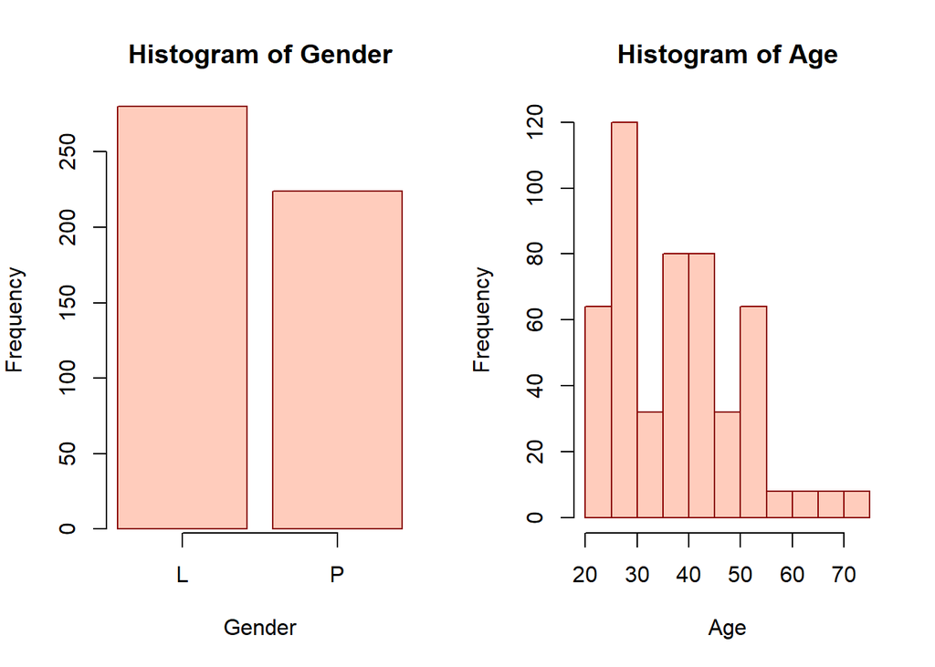

Fig. 1 Gender and Age Histogram

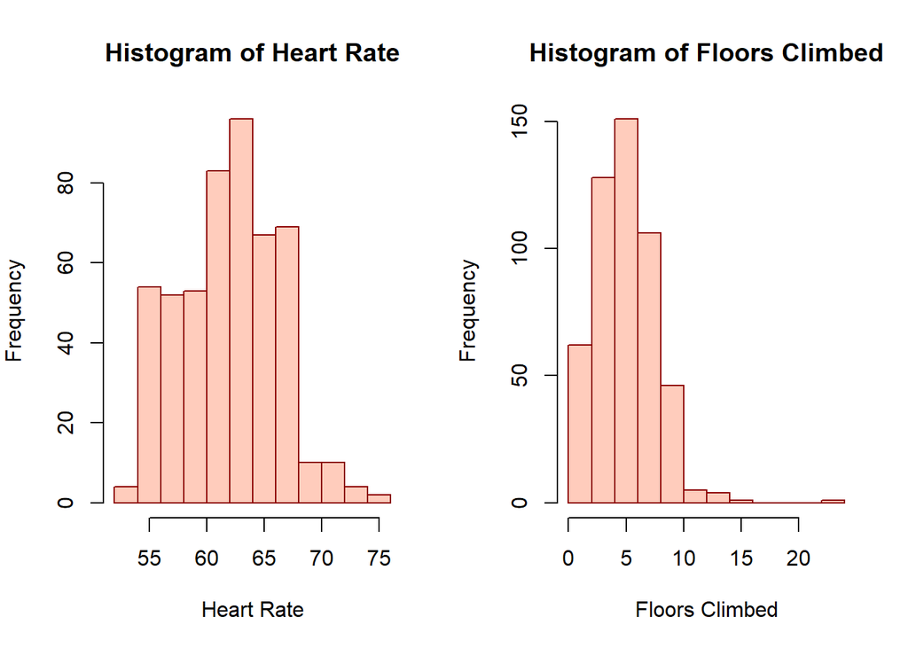

Fig. 3 Heart Rate and Floors Climbed Histogram

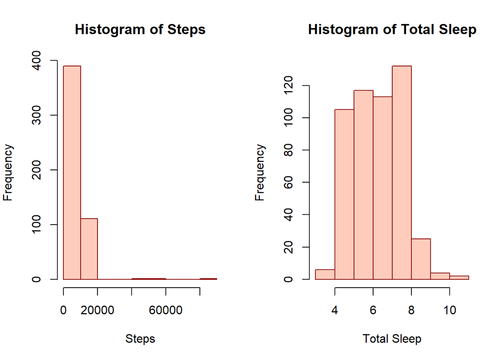

Fig. 2 Total Steps and Total Sleep Histogram

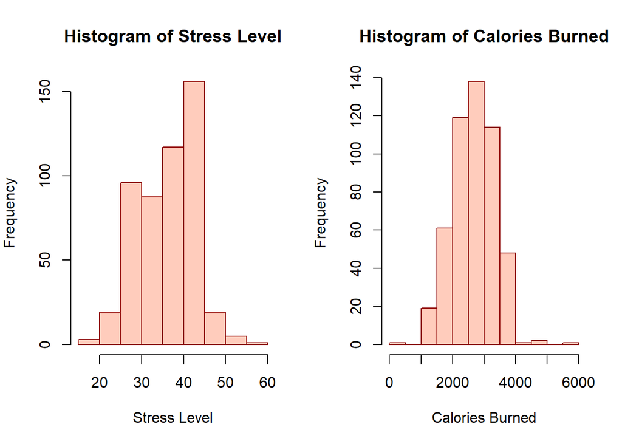

Fig. 4 Stress and Calories Burned Histogram

We can see that from the variables visualized in the histogram above, that only `Calories Burned` seem to be following a normal distribution. On the other hand, `Total Sleep`, `Heart Rate`, and `Stress Level` managed a steeper/sharper distribution than that of a normal distribution. While `Age`, `Steps`, and `Floors Climbed` are following a more skewed distribution.

#### Relationship Between Columns

Moving on from that, next we observed how each of the variables correlate to each other. We are trying to see whether or not meaningful information can be infered using correlation values between two variables.

```r
# remove non-numerical data
a <-data[,-c(1,2,4)]

# creating correlation matrix
corr_mat <- as.data.frame(round(cor(a),2))
```

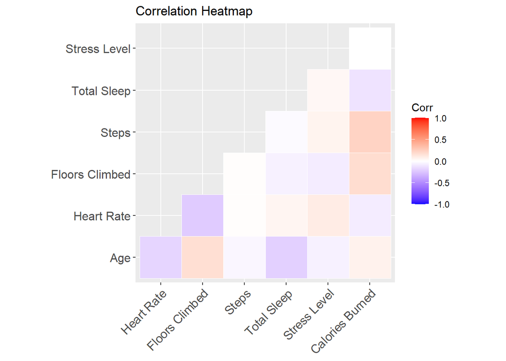

Fig. 5 Correlation Heat Map Between Columns

|  | Age | Heart Rate | Floors Climbed | Steps | Total Sleep | Stress Level | Calories Burned |
| --- | --- | --- | --- | --- | --- | --- | --- |
| Age | 1.00 | -0.18 | 0.17 | -0.04 | -0.20 | -0.06 | 0.07 |
| Heart Rate | -0.18 | 1.00 | -0.22 | 0.01 | 0.05 | 0.10 | -0.08 |
| Floors Climbed | 0.17 | -0.22 | 1.00 | 0.01 | -0.06 | -0.08 | 0.18 |
| Steps | -0.04 | 0.01 | 0.01 | 1.00 | -0.02 | 0.06 | 0.23 |
| Total Sleep | -0.20 | 0.05 | -0.06 | -0.02 | 1.00 | 0.04 | -0.12 |
| Stress Level | -0.06 | 0.10 | -0.08 | 0.06 | 0.04 | 1.00 | 0.00 |
| Calories Burned | 0.07 | -0.08 | 0.18 | 0.23 | -0.12 | 0.00 | 1.00 |

#### Observing Relationship between Columns with Higher Correlation

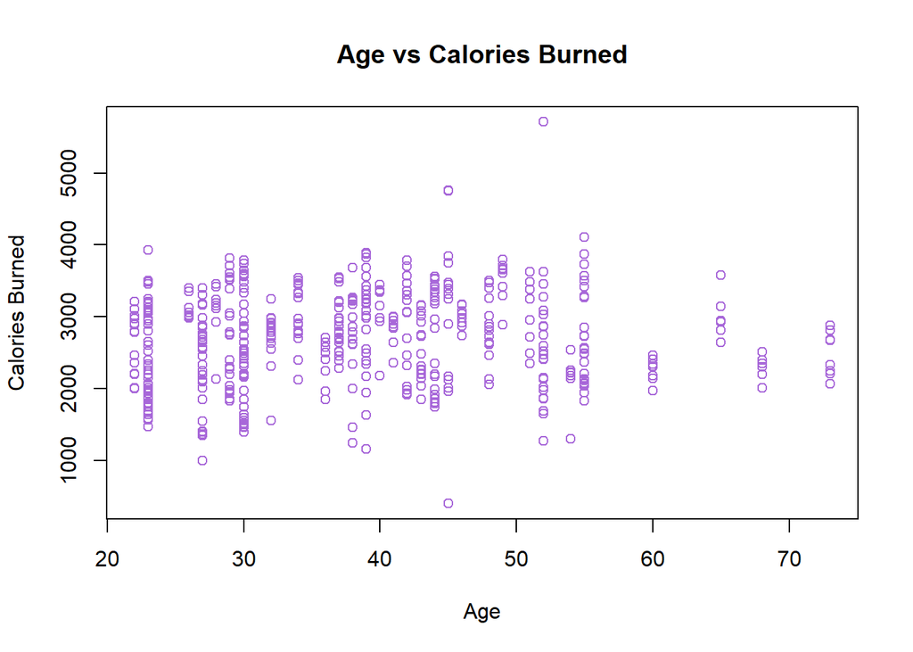

Fig. 6 Relationship Between Calories Burned and Age

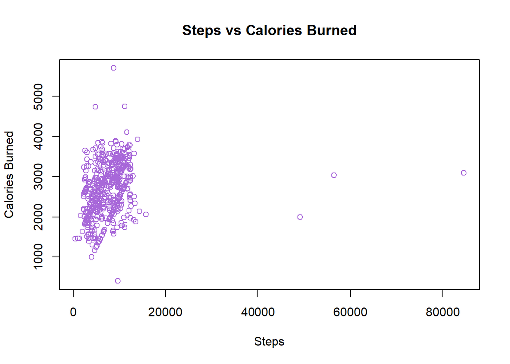

Fig. 7 Relationship Between Calories Burned and Steps

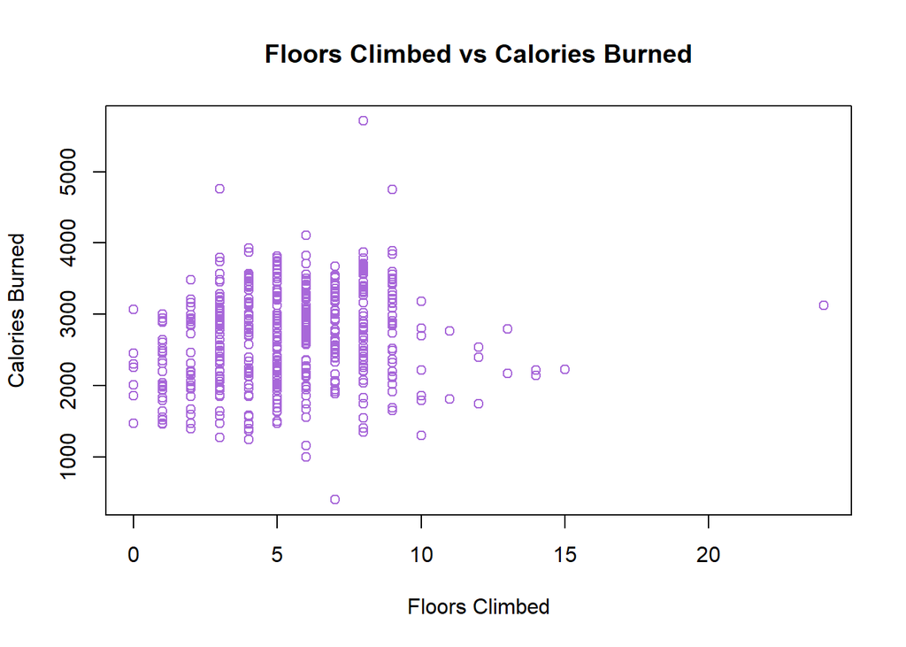

Fig. 8 Relationship Between Calories Burned and Floors Climbed

In Fig. 9 we can see a non-directional relationship between `Stress Level` and `Heart Rate`. It shows that both are factors that influence each other but its directional impact cannot be concluded because the data isn’t collected in a vacuum. The same can be seen in Figures 10 and 11. Where it shows that both variables influence each other but the relationship cannot be defined linearly.

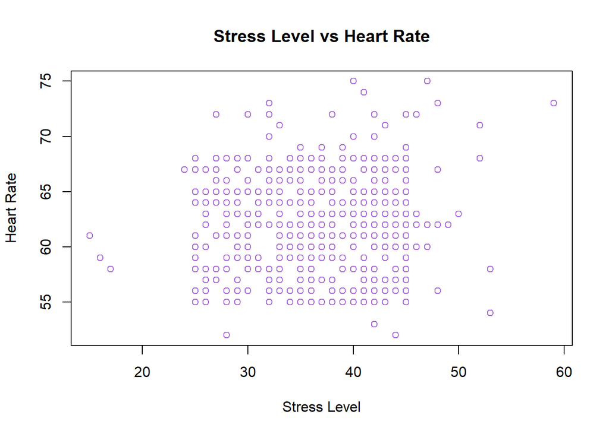

Fig. 9 Relationship Between Stress Level and Heart Rate

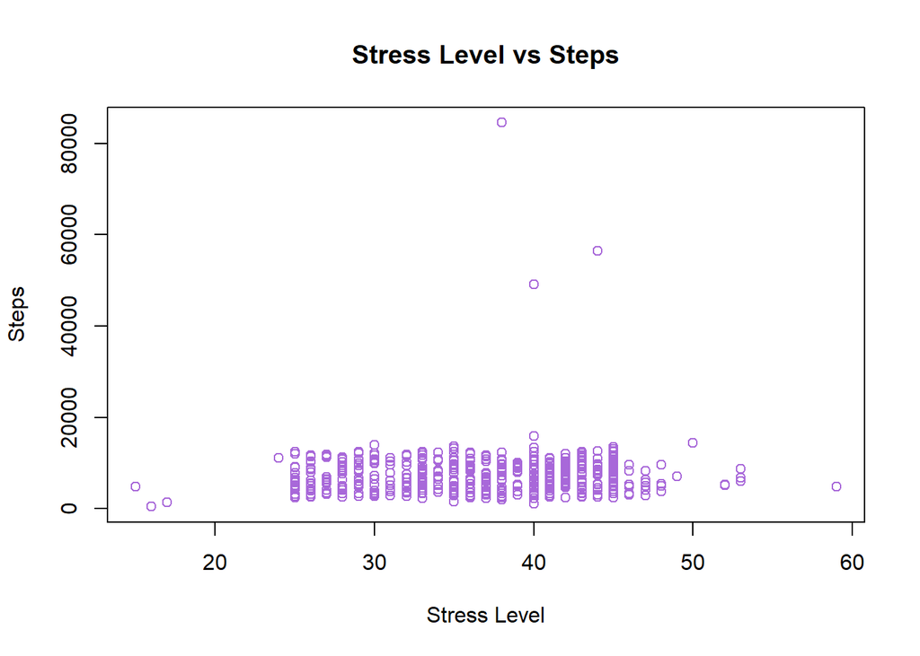

Fig. 10 Relationship Between Stress Level and Steps

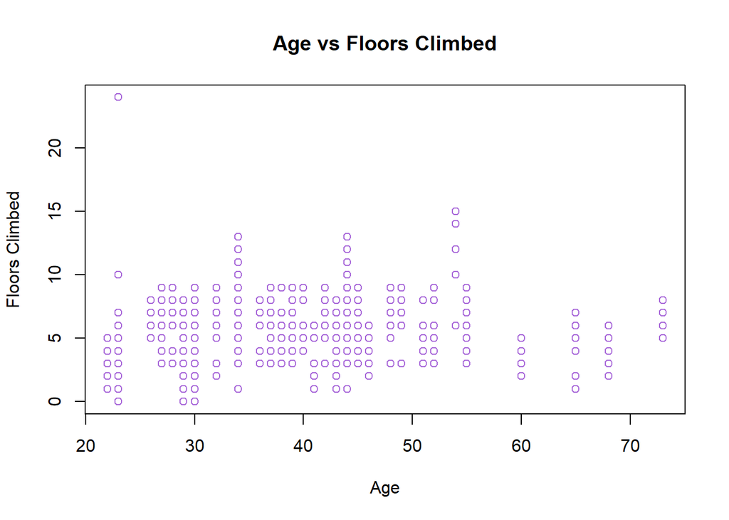

Fig. 11 Relationship Between Age and Floors Climbed

#### Observing behaviour differences among age group

The data above haven’t quite shown the significance of `Age` towards `Calories Burned`. However, Medical News Today published that one of the common factors of calorie loss is age. They said that as a person’s age increases, said person’s ability to burn calories decreases. But since the data fails to show that, we thought that maybe seperating them into age groups may show certain behaviors unique to certain age groups.

```r
# categorizing ages into four age groups
you <- data[which(Age<25),]
yad <- data[which(Age>=25 & Age<35),]
adl <- data[which(Age>=35 & Age<65),]
sen <- data[which(Age>=65),]

age_group <- c(nrow(you), nrow(yad), nrow(adl), nrow(sen))
age_labels <- c('<25', '25-34', '35-64', '>64')
age_percent <- percent(age_group/sum(age_group))
```

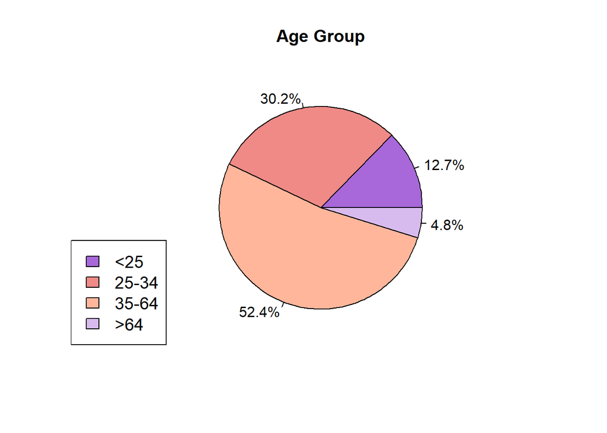

Fig. 12 age Group Pie Chart

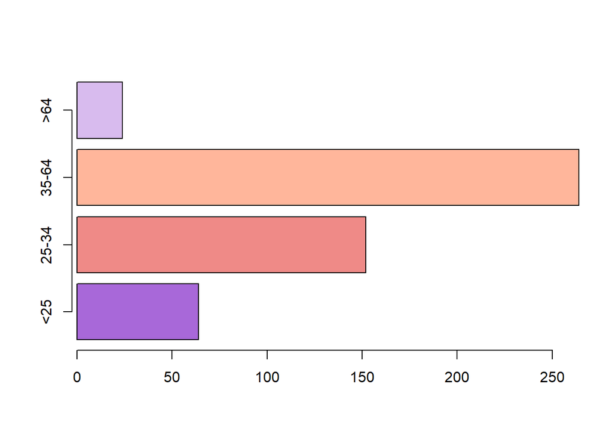

Fig. 13 Age Group Bar Chart

So, using a common age category, we are going to divide the data into four different age groups, labeled *Youth* for subjects ages less than 25, *Young Adults* for subjects ages 25-34, *Adults* for subjects ages 35-64, and *Seniors* for subjects ages 65 and older.

After separating data into 4 different age groups. We will observe for differences or changes in correlations between variables. The results can be seen in correlation heat maps as shown in Figures 14 - 17 below.

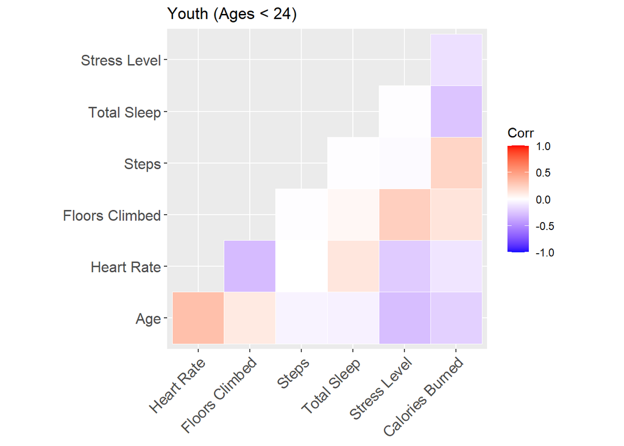

Fig. 14 Correlation Heat Map for Youth

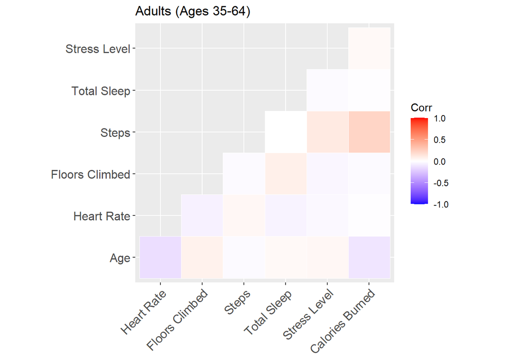

Fig. 15 Correlation Heat Map for Adults

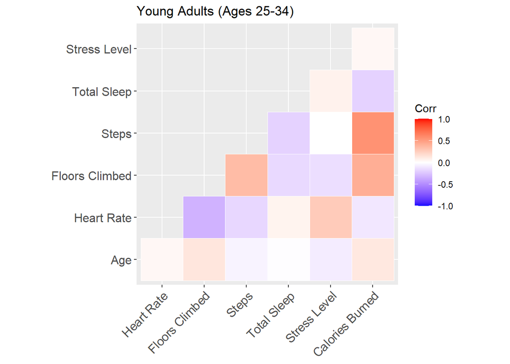

Fig. 16 Correlation Heat Map for Young Adults

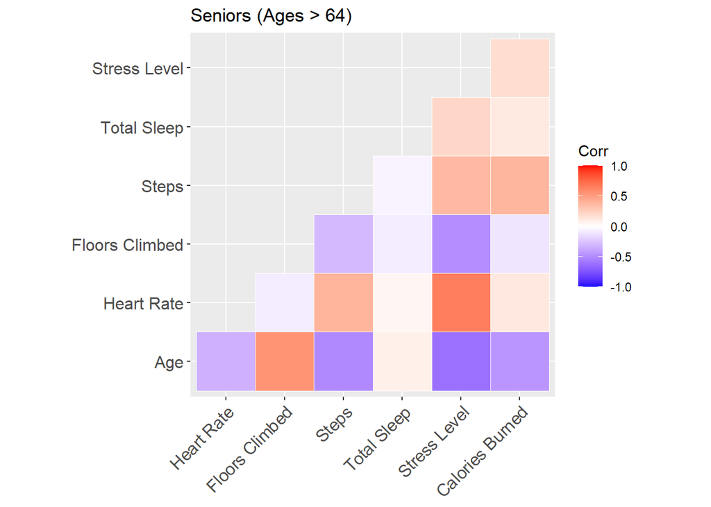

Fig. 17 Correlation Heat Map for Seniors

Before commenting on the differeneces, we would first like to point out that the one variable that maintain high correlation with `Calories Burned` within all age groups is `Steps`. It is interesting that not only was it the variable that shows high positive linear relationship but also high consitency in correlation with `Calories Burned` within different age groups. So, we can confidently say that `Steps` will be one of the indepent variables in predicting `Calories Burned`.  
Although when observing differences in behavior with respect to age groups, no specific variable show trends or distinct difference in behavior. However, it is interesting to see, that as the age group gets older, a lot more factors or variables seem to influence or correlate with each other includign `Calories Burned`. The data may not confirm or deny anything here, but it is an interesting point to further research on.

#### Seperating Training and Testing Data

Since not much else information can be extracted from the complete data, now we are going to continue with the third objective of this analysis. That is to observe the differences in prediction performance between K-Means Clustering and Regression Tree. Before we do that, we will first seperate the data into training data and testing data with a 3:1 ratio.

```r
data_avg <- as.data.frame(read_excel('C:/Users/Sony/Documents/Amadea/RStudio/R Files/Fitbit Charge 3 Insight/data1 - edited.xlsx', sheet='Avg'))
head(data_avg)
```

| Person | Gender | Age | Heart Rate | Floors Climbed | Steps | Total Sleep | Stress Level | Calories Burned |
| --- | --- | --- | --- | --- | --- | --- | --- | --- |
| 1 | P | 23 | 71.375 | 1.875 | 6702.500 | 8.250 | 32.625 | 2368.500 |
| 2 | L | 23 | 60.000 | 6.375 | 9594.125 | 6.250 | 32.500 | 3282.625 |
| 3 | L | 54 | 54.250 | 10.875 | 7212.625 | 7.625 | 38.125 | 2136.000 |
| 4 | P | 44 | 67.500 | 9.250 | 10005.625 | 6.500 | 34.625 | 1881.750 |
| 5 | P | 30 | 60.000 | 2.500 | 3577.875 | 8.625 | 26.250 | 1508.750 |
| 6 | P | 30 | 62.750 | 2.625 | 3117.125 | 7.875 | 39.500 | 1625.375 |

```r
# to randomize data that joins the train data set
index <- sample.int(n = nrow(data_avg), size = floor(.75*nrow(data_avg)), replace = F)

# to separate training data and test data for K-means clustering
data_km <- data_avg[,-c(1,2)]
row.names(data_km) <- c(1:63)
train_km <- data_km[index,]
test_km <- data_km[-index,]

# to separate training data and test data for Regression Tree
train_rt <- data_avg[index,]
test_rt <- data_avg[-index,]
data_rt <- train_rt[,-c(1,4)]
```

#### K-Means Clustering

K-means clustering (MacQueen 1967) is one of the most commonly used unsupervised machine learning algorithm for partitioning a given data set into a set of *k* groups (i.e. *k* clusters), where *k* represents the number of groups pre-specified by the analyst.

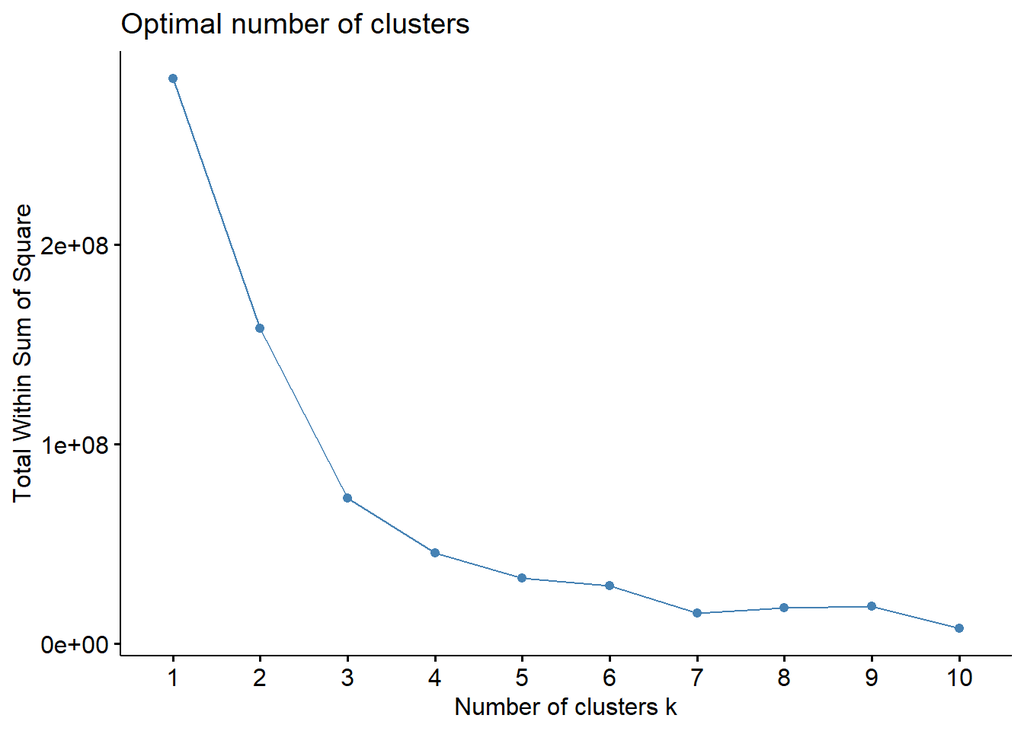

Fig. 18 Plotting Optimal Number of Clusters

The idea is to compute k-means clustering using different values of clusters *k*. Next, the *wss* (within sum of square) is drawn according to the number of clusters. The location of a bend (knee) in the plot is generally considered as an indicator of the appropriate number of clusters.  
The plot to the left represents the variance within the clusters. It decreases as *k* increases, but a bend (or “elbow”) can be seen at *k = 4*. This bend indicates that additional clusters beyond the fourth have little value. So, we are going to perform K-means clustering with *k = 4*

```r
# execute k-means clustering with 4 clusters or centroids
mod_k1 <- kmeans(train_km, centers=4, nstart = 25)
```

K-means clustering with *k = 4* was executed and the results are clusters with means and description of variables as seen on the table below. There are four clusters and theses clusters and categorization will be used to predict `Calories Burned`.

| cluster | Age | Heart Rate | Floors Climbed | Steps | Total Sleep | Stress Level | Calories Burned |
| --- | --- | --- | --- | --- | --- | --- | --- |
| 1 | 39.13 | 62.07 | 5.12 | 9460.51 | 6.48 | 38.18 | 2779.38 |
| 2 | 34.50 | 62.69 | 4.83 | 4668.67 | 6.96 | 37.81 | 2357.10 |
| 3 | 23.00 | 67.00 | 3.50 | 19015.00 | 7.12 | 42.25 | 3047.50 |
| 4 | 41.56 | 61.42 | 6.16 | 7092.34 | 6.61 | 35.38 | 2751.09 |

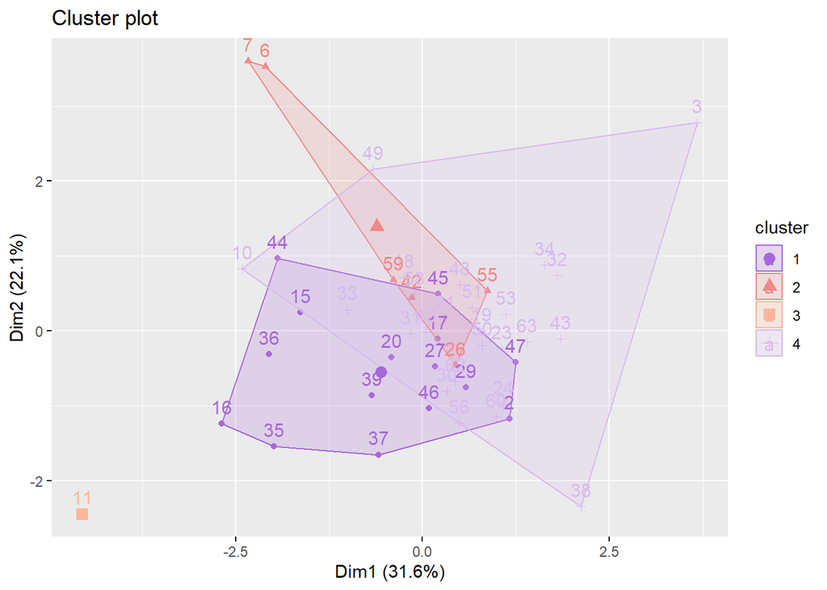

Now that we have created and defined the clusters, we are able to use these cluster criteria to predict the `Calories Burned` by using the information given by the `test` data. The results of the prediction and the percentage of error in prediction by the K-means Clustering model can be seen below.

```r
options(width = 110)
yhat_clus1 <- clus1$`Calories Burned`[cl_predict(mod_k1, test_km)]
yhat_clus1
```

```
##  [1] 2751.093 2779.375 2357.104 2779.375 2357.104 2357.104 2751.093 2779.375 2751.093 2751.093 2751.093
## [12] 2779.375 2751.093 2357.104 2357.104 2751.093
```

```r
total_actual_km <- sum(test_km$`Calories Burned`)
total_clus1 <- sum(yhat_clus1)
percentage_error_km <- abs(total_actual_km-total_clus1)/(total_actual_km)
percentage_error_km
```

```
## [1] 0.01056858
```

#### Regression Tree

According to investigations about the data and relationships between variables and `Calories Burned`, we saw that most of the relationship cannot be drawn linearly. Given that the relationship between a set of predictors and a response is more complex, then non-linear methods can often produce more accurate models. One of the more commonly use non-linear methods of anlysis is classification and regression trees.

Classification and Regression Tree (CART) use a set of predictor variable to build decision trees that predict the value of a response variable. Since the response variable is continuos, Regression Tree is the one we would use.

```r
# using regression tree function
tree1 <- rpart(`Calories Burned`~., data=data_rt, control=rpart.control(cp=.0001))
printcp(tree1)
```

```
##
## Regression tree:
## rpart(formula = `Calories Burned` ~ ., data = data_rt, control = rpart.control(cp = 1e-04))
##
## Variables actually used in tree construction:
## [1] Floors Climbed Steps          Stress Level
##
## Root node error: 11723467/47 = 249435
##
## n= 47
##
##         CP nsplit rel error xerror    xstd
## 1 0.161134      0   1.00000 1.0470 0.20282
## 2 0.075488      1   0.83887 1.2267 0.20697
## 3 0.000100      3   0.68789 1.2101 0.21005
```

The regression tree analysis was executed and the results can be visualized in the form of the decision tree itself as attached below.

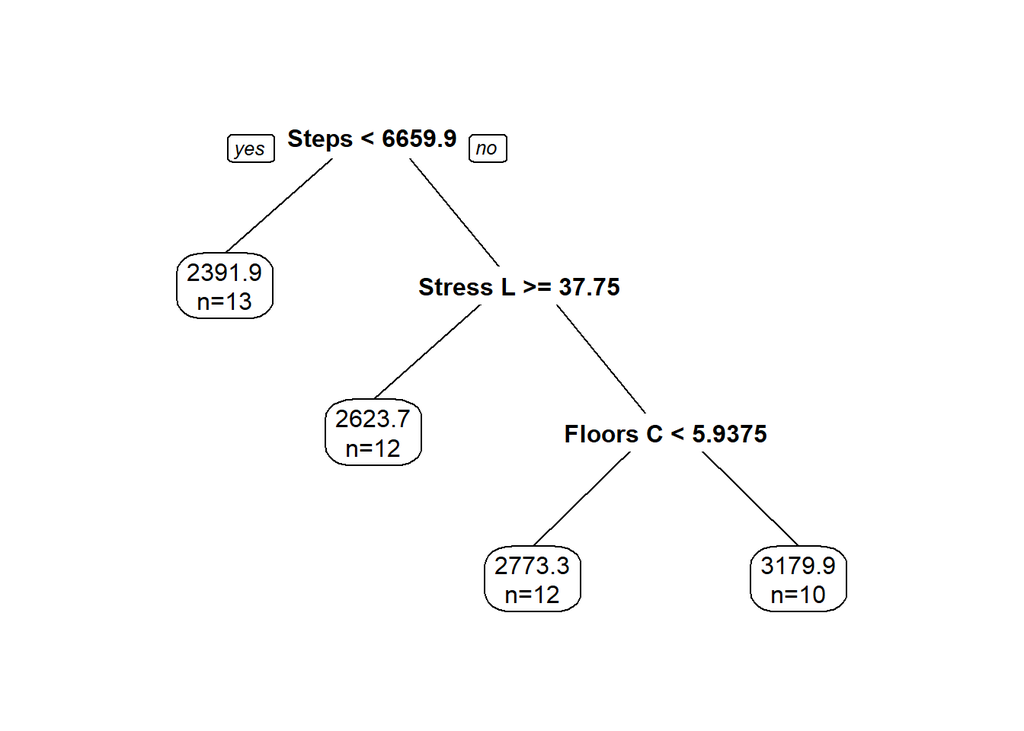

```r
#plot the final tree
prp(tree1,
    faclen=0, #use full names for factor labels
    extra=1, #display number of obs. for each terminal node
    roundint=F, #don't round to integers in output
    digits=5) #display 5 decimal places in output
```

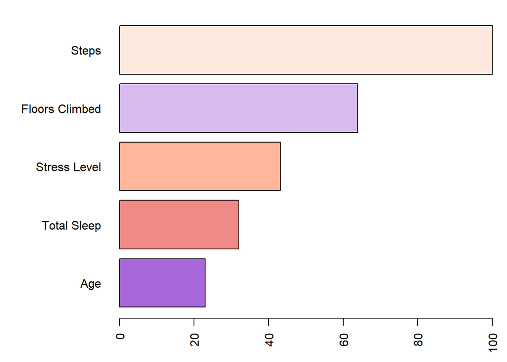

```r
# displaying order of variable importance
vImp <- tree1$variable.importance
vImp <- vImp*100/max(vImp)
ind <- order(vImp)
par(las=2)
par(mar=c(3,8,1,1))
barplot(vImp[ind],main="", horiz=TRUE, names.arg=names(vImp[ind]), col = c("#a868d9", "#EF8A87", "#FFB69B", "#D8BBEE", "#FDE9DD", "#F7E7FB"))
```

Pruning would be necessary if the number of branches are enormous. However since, the model we obtained has a limited amount, pruning won’t be necessary. Now that we have created this Regression Tree model, we can use it to decide or predict `Calories Burned` of the `test` data. The results of the prediction can be seen below, as well as the percentage of error in prediction by the Regression Tree.

```r
yhat_tree1 <- predict(tree1, test_rt)
head(yhat_tree1)
```

```
##        1        4        5        8        9       12
## 2773.281 3179.900 2391.909 2623.740 2391.909 2391.909
```

```r
total_actual_rt <- sum(test_rt$`Calories Burned`)
total_tree1 <- sum(yhat_tree1)
percentage_error_rt <- abs(total_actual_rt-total_tree1)/(total_actual_rt)
percentage_error_rt
```

```
## [1] 0.01747678
```